# sfig9 and efig5b: Spacing of Motifs across Transposable Elements

Melanie (1028-02098-001-001)

December 01, 2020

# Introduction

Motif pairs occur across transposable elements at different spacing than others. Show this in a histogram (expanded results) and ranked plot format (summarized results).

# Computational Setup

```r
#Standard packages
library(rtracklayer) ; library(GenomicRanges); library(magrittr) ; library(Biostrings)
library(ggplot2) ; library(reshape2); library(plyranges); library(Rsamtools); library(data.table)
library(BSgenome.Mmusculus.UCSC.mm10); library(plyr); library(viridis); library(dplyr)

#KNITR Options
setwd("/n/projects/mw2098/publications/2019_bpnet/")
options(knitr.figure_dir="figures/22-sfig9_efig5b-strict-motif-spacing", width=16, height=20)

#Lab sources
source("rscripts/granges_common.r")
source("rscripts/metapeak_common.r")
source("rscripts/knitr_common.r")
source("rscripts/caching.r")
source("rscripts/multiplot.R")

#Specific packages
library(ggrepel)
```

# Define data paths

```r
motif_pair_filepath<-"data/csv/motif_pairs.csv" #see "generation of motif pairs" below for description of how data was generated
```

## Generation of motif pairs

`data/csv/dfi_subset.csv` was generated in the SnakeMake file, refer to this for further details.

Motif pairs were generated in the corresponding `22-sfig9_efig5b-strict-motif-spacing_get_motif_pairs.ipynb`.

# Import motif pairs and mark for palindromic instances

Generate GRanges for each motif instance and the entire motif pair span.

If the motif pairs are between each other, then there could be a palindromic strict spacing that is artificial. Because of this, we will apply a filter that removes overlapping motifs in cases where the motif pairs are the same motif.

```r
#Import motif pairs
motif_pairs_with_tes<-read.csv(motif_pair_filepath)

#Determine whether motifs being compared are the same PATTERNS
motif_pairs_with_tes$is_same_motif<-(motif_pairs_with_tes$pattern_x == motif_pairs_with_tes$pattern_y) %>% as.character

#Create GRanges
motif_pairs_with_tes_x.gr<-motif_pairs_with_tes %>%
  makeGRangesFromDataFrame(keep.extra.columns = T, start.field = "pattern_start_abs_x",
                           end.field = "pattern_end_abs_x", strand.field = "strand_x",
                           seqnames.field="example_chrom_x", starts.in.df.are.0based = T)
motif_pairs_with_tes_y.gr<-motif_pairs_with_tes %>%
  makeGRangesFromDataFrame(keep.extra.columns = T, start.field = "pattern_start_abs_y",
                           end.field = "pattern_end_abs_y", strand.field = "strand_y",
                           seqnames.field="example_chrom_x", starts.in.df.are.0based = T)


#Determine whether motif  are overlapping
overlaps_all<-findOverlaps(motif_pairs_with_tes_x.gr, motif_pairs_with_tes_y.gr, ignore.strand=TRUE) %>% as.data.frame
overlapping_rows<-overlaps_all$queryHits[which(overlaps_all$queryHits==overlaps_all$subjectHits)]
motif_pairs_with_tes$motifs_overlapping<-FALSE
motif_pairs_with_tes$motifs_overlapping[overlapping_rows]<-TRUE

#Create Granges with the coverage spanning both motif pairs
starts<-data.frame(x=start(motif_pairs_with_tes_x.gr), y=start(motif_pairs_with_tes_y.gr))
starts<-lapply(1:nrow(starts), function(x){min(as.numeric(starts[x,]))}) %>% unlist
ends<-data.frame(x=end(motif_pairs_with_tes_x.gr), y=end(motif_pairs_with_tes_y.gr))
ends<-lapply(1:nrow(ends), function(x){max(as.numeric(ends[x,]))}) %>% unlist
motif_pair.gr<-GRanges(seqnames(motif_pairs_with_tes_x.gr), IRanges(start=starts, end=ends), strand="*")
```

# Annotate motif pairs with two interpretations of TE overlaps

We have two interpretations of what is a TE:

1. Annotations by RepeatMasker
2. Criteria defined by type of seqlet returned

These are both very similar but are not completely identical.

# Import and format repeatmasker regions

Note that `repeatmasker.mm10.gr.rds` file is a GRanges conversion from the `repeatmasker.mm10.fa.out`. The following code involves the formatting:

```bash
#RepeatMasker open-4.0.5
cd /n/projects/mw2098/publications/2019_bpnet/data/
wget http://www.repeatmasker.org/genomes/mm10/RepeatMasker-rm405-db20140131/mm10.fa.out.gz
gunzip mm10.fa.out.gz
```

```r
repeats.df<-read.table("data/mm10.fa.out", header=FALSE, sep="", skip=3, as.is=TRUE, col.names=1:15, fill=TRUE)
colnames(repeats.df)<-c("SW_score","perc_div","perc_del","perc_ins","chr","start","end","left","strand",
                        "matching_repeat","repeat_class","position_start","position_end","repeat","id")
repeats.df$strand[repeats.df$strand=="C"]<-"-"
repeats.gr<-makeGRangesFromDataFrame(repeats.df, keep.extra.columns = T, starts.in.df.are.0based = T)
saveRDS(repeats.gr, "data/rdata/repeatmasker.mm10.gr.rds")
```

## Annotate repeatmasker TEs

```r
rmask<-readRDS("data/rdata/repeatmasker.mm10.gr.rds")
overlaps<-findOverlaps(rmask, motif_pair.gr, ignore.strand=T)
overlaps_all_idx<-overlaps@to %>% unique

motif_pairs_with_tes$is_te_by_rmask<-"no"
motif_pairs_with_tes$is_te_by_rmask[overlaps_all_idx]<-"yes"
motif_pairs_with_tes$is_te_by_rmask<-factor(motif_pairs_with_tes$is_te_by_rmask, levels=c("yes", "no"))
```

## Annotate ERV TEs

We noticed that many of the long motifs that are across TEs are classified as TEs. How different are these results?

```r
erv_idx<-grep(pattern = paste(c("ERV"), sep="", collapse="|"), x = rmask$repeat_class, ignore.case = T) %>% unique
message(round(length(erv_idx) / length(rmask), 2), " % of RepeatMasker elements will be used as erv filter.")
ervs<-rmask[erv_idx]

#Find overlaps of ervs and motif pairs
overlaps_ervs<-findOverlaps(ervs, motif_pair.gr, ignore.strand=T)
overlaps_all_erv_idx<-overlaps_ervs@to %>% unique

#Label based on dfs
motif_pairs_with_tes$is_te_by_erv<-"no"
motif_pairs_with_tes$is_te_by_erv[overlaps_all_erv_idx]<-"yes"
motif_pairs_with_tes$is_te_by_erv<-factor(motif_pairs_with_tes$is_te_by_erv, levels=c("yes", "no"))

message(round((which(motif_pairs_with_tes$is_te_by_erv=="no" & motif_pairs_with_tes$is_te_by_rmask=="yes") %>% length) / nrow(motif_pairs_with_tes), 2), " of regions contain non-erv TEs.")

#Label class of ERV that was binned
erv_classes<-ervs[overlaps_ervs@from[!duplicated(overlaps_ervs@to)]]$repeat_class #select ervs that are not duplicated and overlap with motifs
motif_pairs_with_tes$erv_class<-"Not ERV"
motif_pairs_with_tes$erv_class[overlaps_all_erv_idx]<-erv_classes

#Clean up ERVK classes
motif_pairs_with_tes$erv_class[motif_pairs_with_tes$erv_class=="LTR/ERVK?"]<-"LTR/ERVK"
motif_pairs_with_tes$erv_class[motif_pairs_with_tes$erv_class=="LTR/ERVL?"]<-"LTR/ERVL"
motif_pairs_with_tes$erv_class[motif_pairs_with_tes$erv_class=="LTR/ERV1?"]<-"LTR/ERV1"
```

Check the overlap difference once you only filter for Class 1 TEs.

```r
which(motif_pairs_with_tes$is_te_by_retro=="no" & motif_pairs_with_tes$is_te_by_rmask=="yes") %>% length
```

```
## [1] 0
```

It seems that there are no class 2 repeatmasker elements that overlap with any motif pair locations.

## Annotate “criteria” TEs

```r
motif_pairs_with_tes$is_te_by_criteria<-"no"
motif_pairs_with_tes$is_te_by_criteria[which(motif_pairs_with_tes$is_te_x=="True" | motif_pairs_with_tes$is_te_y=="True")]<-"yes"
motif_pairs_with_tes$is_te_by_criteria<-factor(motif_pairs_with_tes$is_te_by_criteria, levels=c("yes", "no"))
```

# Plot motif pair histogram with ERV-filter (class 1 retrotransposon subset)

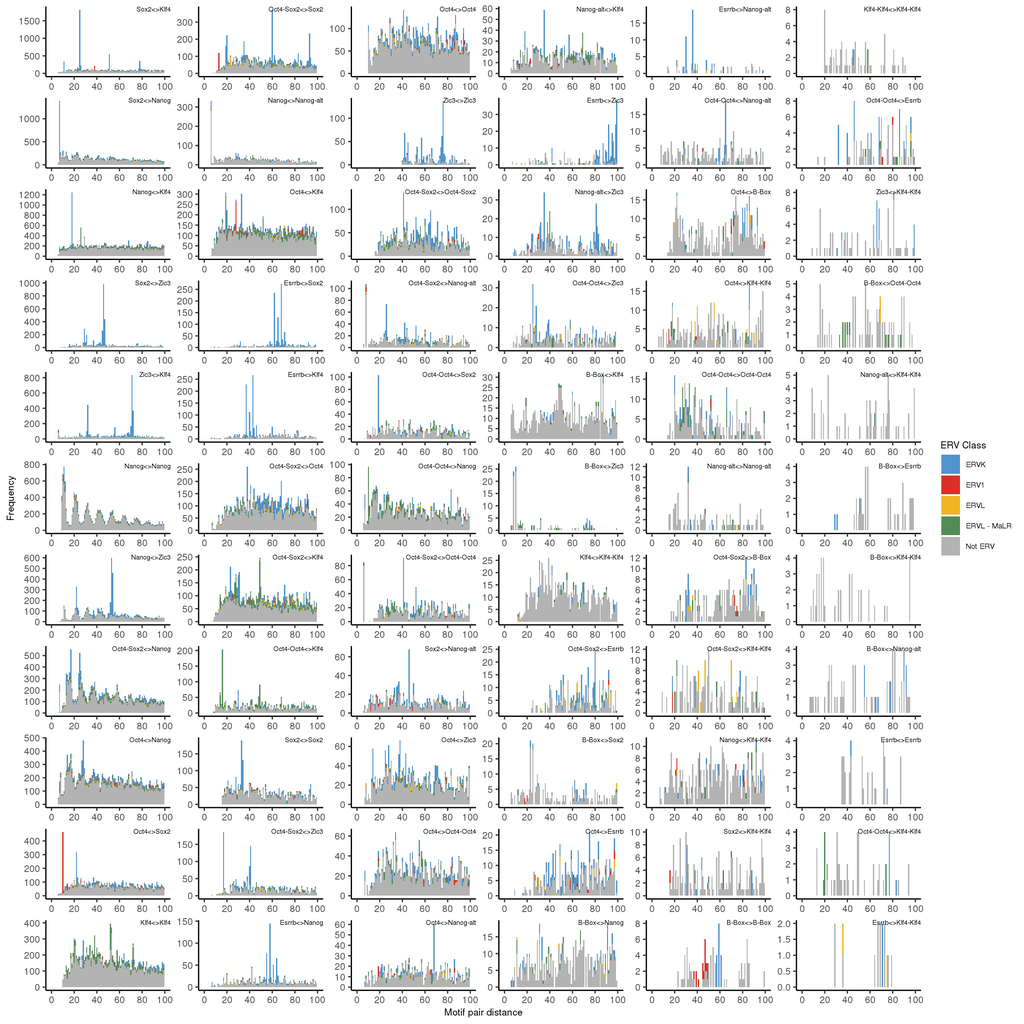

```r
plot_motif_pair_histogram<-function(df, max_dist = 100, min_dist = 6){
  #Reassign the data
  motif_pairs_with_tes_erv_plot<-subset(df, center_diff <= max_dist & center_diff >= min_dist)
  motif_pairs_with_tes_erv_plot$erv_class<-factor(motif_pairs_with_tes_erv_plot$erv_class,
                                         levels=c("LTR/ERVK", "LTR/ERV1", "LTR/ERVL", "LTR/ERVL-MaLR", "Not ERV"),
                                         labels=c("ERVK", "ERV1", "ERVL", "ERVL - MaLR","Not ERV"))
  motif_pairs_with_tes_erv_plot$motif_pair<-gsub("Essrb", "Esrrb", motif_pairs_with_tes_erv_plot$motif_pair) #rename to correct mistake in earlier annotations
  motif_pairs_with_tes_erv_plot$motif_pair<-gsub("Nanog-partner", "Nanog-alt", motif_pairs_with_tes_erv_plot$motif_pair) #rename to correct mistake in earlier annotations

  #Order and factor data
  motif_pairs_with_tes_motif_pair_counts<- motif_pairs_with_tes_erv_plot %>%
    group_by(motif_pair) %>% dplyr::summarize(max_count=max(table(center_diff)))
  motif_pairs_with_tes_motif_pair_counts<-motif_pairs_with_tes_motif_pair_counts[order(motif_pairs_with_tes_motif_pair_counts$max_count, decreasing=T),]
  motif_pairs_with_tes_erv_plot$motif_pair<-factor(motif_pairs_with_tes_erv_plot$motif_pair, levels=motif_pairs_with_tes_motif_pair_counts$motif_pair)

  #Label the facets on the body of the plot, not the facet labels (saves space)
  label=data.frame(motif_pair = unique(as.character(motif_pairs_with_tes_erv_plot$motif_pair)))
  label$motif_pair<-factor(label$motif_pair, levels=motif_pairs_with_tes_motif_pair_counts$motif_pair)


  #Format breaks to be pretty
  library(scales)
  #int_breaks <- function(x, n = 5) pretty(x, n)[pretty(x, n) %% 1 == 0]

  g<-ggplot(motif_pairs_with_tes_erv_plot)+
    geom_histogram(aes(x=center_diff, fill=erv_class), binwidth = 1)+#, color="black", size=.05)+
    geom_text(data = label, aes(x=Inf, y=Inf, label = motif_pair), hjust=1, vjust=1, size=2)+
    facet_wrap(~ motif_pair, scales="free", ncol = 6, dir="v")+
    scale_x_continuous(breaks=seq(0, max_dist, 20), limits=c(0, max_dist), name="Motif pair distance")+
    scale_y_continuous(name="Frequency", breaks=pretty_breaks())+
    scale_fill_manual(values=c("steelblue3", "#d73027", "goldenrod2", "palegreen4", "gray70"), name="ERV Class")+
    theme_classic()+
    theme(text=element_text(size=8), strip.text = element_text(size=8), legend.position="right",
          axis.text = element_text(size=8),
          #strip.text.y = element_text(angle = 0, size=8),
          strip.text.x = element_blank(), strip.background = element_blank(),
          panel.grid.major.y = element_line(color="gray100"),
          panel.grid.major.x = element_line(color="gray100"))#, panel.border = element_rect(color="black"))
  print(g)
  return(NULL)
}

#plot while removing palindromes
plot_motif_pair_histogram(df = motif_pairs_with_tes[-which(motif_pairs_with_tes$is_same_motif==TRUE & motif_pairs_with_tes$motifs_overlapping==TRUE),])
```

The ERV TEs are the best way of organizing this spacing. You can see that most strict spacings are associated with ERV classes.

# Aggregate histograms

## Define motif pairs

Motif pairs without palindromic atrifacts will be used:

```r
motif_pairs_with_tes_no_palindromes<-motif_pairs_with_tes[-which(motif_pairs_with_tes$is_same_motif==TRUE & motif_pairs_with_tes$motifs_overlapping==TRUE),]
motif_pairs_with_tes_no_palindromes$motif_pair<-gsub("Essrb", "Esrrb", motif_pairs_with_tes_no_palindromes$motif_pair) #rename to correct mistake in earlier annotations
motif_pairs_with_tes_no_palindromes$motif_pair<-gsub("Nanog-partner", "Nanog-alt", motif_pairs_with_tes_no_palindromes$motif_pair) #rename to correct mistake in earlier annotations
```

## Frequency of spacings vs ERV class

```r
#Function to compute significance based on the motif pairs provided.
motif_pair_erv_frequencies<-function(df, spacing_count_threshold=0, max_dist = 100, min_dist = 6){
  #Filter motifs for processing
  motif_pairs_with_tes_filtered<-subset(df, center_diff <= max_dist & center_diff >= min_dist)
  motif_pairs_with_tes_filtered$motif_pair<-gsub("Essrb", "Esrrb", motif_pairs_with_tes_filtered$motif_pair) #rename to correct mistake in earlier annotations
  motif_pairs_with_tes_filtered$motif_pair<-gsub("Nanog-partner", "Nanog-alt", motif_pairs_with_tes_filtered$motif_pair) #rename to correct mistake in earlier annotations


  #Generate counts and total counts
  pair_freq_erv<-motif_pairs_with_tes_filtered %>% group_by(is_te_by_erv, motif_pair, center_diff) %>% dplyr::summarize(count=n()) #count frequencies of center_diff
  pair_freq_erv_motif_total<-motif_pairs_with_tes_filtered %>% group_by(motif_pair) %>% dplyr::summarize(total_motif_counts=n()) #count frequencies of center_diff
  pair_freq_erv_motif_total<-pair_freq_erv_motif_total[order(pair_freq_erv_motif_total$total_motif_counts, decreasing=T),]

  #Filter out motif pairs that occur too infrequently to have a reliable spacing distribution.
  motif_pairs_to_keep<-pair_freq_erv_motif_total$motif_pair[which(pair_freq_erv_motif_total$total_motif_counts>=spacing_count_threshold)]
  pair_freq_erv<-pair_freq_erv[pair_freq_erv$motif_pair %in% motif_pairs_to_keep,]

  #Normalize to total motifs
  pair_freq_erv<-merge(pair_freq_erv, pair_freq_erv_motif_total, by.x="motif_pair", by.y="motif_pair")
  pair_freq_erv$count_norm_by_motif_totals<-pair_freq_erv$count/pair_freq_erv$total_motif_counts

  #Rank the counts
  pair_freq_erv<-pair_freq_erv[order(pair_freq_erv$count_norm_by_motif_totals, decreasing = T),]
  pair_freq_erv$row<-1:nrow(pair_freq_erv)
  return(pair_freq_erv)
}

spacing_vs_class_freq<-motif_pair_erv_frequencies(df = motif_pairs_with_tes_no_palindromes)
```

## Rank based on counts frequency with thresholded values

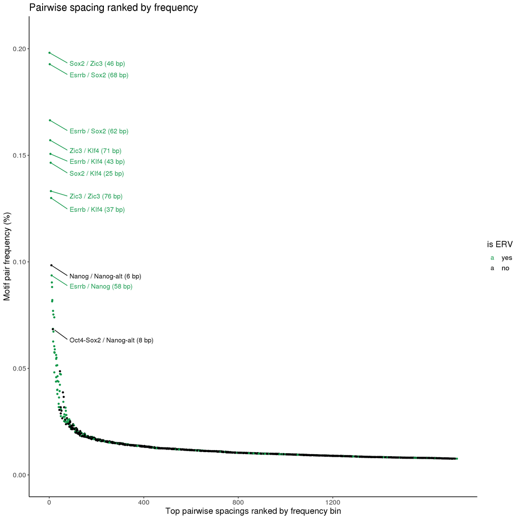

```r
plot_motif_pair_rankings<-function(df, spacing_count_threshold=0, top_annotation_idx=10, max_dist = 100, min_dist = 6){

  #Filter motifs for processing
  motif_pairs_with_tes_filtered<-subset(df, center_diff <= max_dist & center_diff >= min_dist)

  #Generate counts and total counts
  pair_freq_erv<-motif_pairs_with_tes_filtered %>% group_by(is_te_by_erv, motif_pair, center_diff) %>% dplyr::summarize(count=n()) #count frequencies of center_diff
  pair_freq_erv_motif_total<-motif_pairs_with_tes_filtered %>% group_by(motif_pair) %>% dplyr::summarize(total_motif_counts=n()) #count frequencies of center_diff
  pair_freq_erv_motif_total<-pair_freq_erv_motif_total[order(pair_freq_erv_motif_total$total_motif_counts, decreasing=T),]

  #Filter out motif pairs that occur too infrequently to have a reliable spacing distribution.
  motif_pairs_to_keep<-pair_freq_erv_motif_total$motif_pair[which(pair_freq_erv_motif_total$total_motif_counts>=spacing_count_threshold)]
  pair_freq_erv<-pair_freq_erv[pair_freq_erv$motif_pair %in% motif_pairs_to_keep,]

  #Normalize to total motifs
  pair_freq_erv<-merge(pair_freq_erv, pair_freq_erv_motif_total, by.x="motif_pair", by.y="motif_pair")
  pair_freq_erv$count_norm_by_motif_totals<-pair_freq_erv$count/pair_freq_erv$total_motif_counts

  #Rank the counts
  pair_freq_erv<-pair_freq_erv[order(pair_freq_erv$count_norm_by_motif_totals, decreasing = T),]
  pair_freq_erv$row<-1:nrow(pair_freq_erv)

  #Top ERVK annotations
  pair_freq_erv_top_ann<-pair_freq_erv[c(1:top_annotation_idx, which(pair_freq_erv$motif_pair=="Oct4-Sox2<>Nanog-alt")[1]),]

  #Top regions for plotting
  pair_freq_erv_plot_topregions<-pair_freq_erv[which(pair_freq_erv$row<quantile(pair_freq_erv$row, .25) %>% round),]

  erv_jitter_plot<-ggplot()+
    geom_point(data = pair_freq_erv_plot_topregions[1:13, ], aes(x=row, y=count_norm_by_motif_totals, color=is_te_by_erv), size=1) + #, height=.0005)+
    geom_jitter(data = pair_freq_erv_plot_topregions[14:30, ], aes(x=row, y=count_norm_by_motif_totals, color=is_te_by_erv), width = 5, size=1) + #, height=.0005)+
    geom_jitter(data = pair_freq_erv_plot_topregions[31:nrow(pair_freq_erv_plot_topregions),],
                aes(x=row, y=count_norm_by_motif_totals, color=is_te_by_erv), width = 15, size=1) + #, height=.0005)+
    geom_label_repel(data=pair_freq_erv_top_ann,
               aes(x=row, y=count_norm_by_motif_totals, color=is_te_by_erv,
                   label=paste(gsub(pattern = "<>", replacement = " / ", motif_pair), " (", center_diff," bp)", sep="")),
               hjust=0, vjust=.5, label.size = NA, xlim = c(75, NA), force=1, point.padding = .25, box.padding = .05, nudge_y = -.005)+
    scale_x_continuous(breaks=seq(0, 1300, 400), name="Top pairwise spacings ranked by frequency bin")+
    scale_y_continuous(name="Motif pair frequency (%)", limits = c(0, .205))+
    scale_color_manual(values=c("#12984A", "black"), name="is ERV")+
    ggtitle("Pairwise spacing ranked by frequency")+
    theme_classic()+
    theme(text=element_text(size=14))
  print(erv_jitter_plot)
  # ggsave(output_pdf, erv_jitter_plot, height=4, width=6) #, device=cairo_pdf)
  return(pair_freq_erv)
}

pair_freq_erv<-plot_motif_pair_rankings(df = motif_pairs_with_tes_no_palindromes, spacing_count_threshold = 500)
```

# Check rate of ERVs

```r
check_erv_rate<-function(top_percent, frequency_table){
  frequency_table<-frequency_table[order(frequency_table$count_norm_by_motif_totals, decreasing=T),]
  top_freqs<-frequency_table[1:round(top_percent*nrow(frequency_table)),]
  is_erv<-(top_freqs$is_te_by_erv == "yes") %>% sum
  is_erv_percent<-round(is_erv/nrow(top_freqs),2)
  print(paste("The top ", top_percent, " of spacings contain ", is_erv_percent, " as ERVs.", sep=""))
}
lapply(c(0.01), function(x) check_erv_rate(x, frequency_table = pair_freq_erv)) #with thresholds
```

```
## [1] "The top 0.01 of spacings contain 0.83 as ERVs."
```

```
## [[1]]
## [1] "The top 0.01 of spacings contain 0.83 as ERVs."
```

# Conclusions

- Motif pairs across transposable elements do not follow typical spacing dynamics.
- Strict spacing is largely due to motif pairs across transposable elements.
  - When we see large counts across specific spacing, this is indicative of a TE.